# Analyzing logger data

Ariana S Huffmyer

10/10/2022

This script reads and plots logger environmental data from Hobo pendant loggers in the E5 *A. pulchra* metabolism experiment.

# Set Up

```r
library(tidyverse)
library(stringr)
library(readxl)
library(purrr)
library(lubridate)
library(ggplot2)
library(seacarb)
library(broom)
library(cowplot)
```

# Loggers: Pendants in E5 tanks

## Read in files

Read in Hobo Pendant files

```r
pendant.files <- list.files(path="data/environmental/loggers/E5_tanks", pattern="*.xlsx", full.names=TRUE)

pendants <- setNames(pendant.files, pendant.files) %>%
   map_dfr(read_excel, .id = "logger") %>%
   rename(DateTime=`Date-Time (French Polynesia Standard Time)`, temp.C=`Ch: 1 - Temperature   (°C )`, light.lux=`Ch: 2 - Light   (lux)`)%>%
  select(!`#`)%>%
  mutate(logger=sub(".*/", "", logger))%>% #remove the path name
  mutate(logger=sub("_.*", "", logger)) #keep only the serial number

pendants$DateTime<-as.POSIXct(pendants$DateTime, format="%m/%d/%y %H:%M:%S", tz="Pacific/Tahiti")

#adjust time to correct values and force time zone
pendants$DateTime <- force_tz(pendants$DateTime, tzone = "Pacific/Tahiti")
```

## Read in treatment information

Read in metadata that assigns a pendant serial number to a tank number and/or treatment.

```r
metadata<-read_csv("data/environmental/loggers/E5_tanks/logger_metadata.csv")
metadata$logger<-as.character(metadata$logger)
```

Assign treatment information to logger data.

```r
pendants<-left_join(pendants, metadata, by="logger")
pendants$tank<-as.factor(pendants$tank)
```

## Apply tempreature calibrations

Read in calibration output file with the intercept and coefficients for calibration.

```r
temp_cal<-read_csv("output/environmental/temperature_logger_calibrations.csv")
temp_cal$logger<-as.character(temp_cal$logger)
```

Generate a calibrated temperature column in our logger dataframe.

```r
pendants<-left_join(pendants, temp_cal, by="logger")

pendants<-pendants%>%
  mutate(temp.calibrated=temp.C*coef+intercept)%>%
  select(!coef)%>%
  select(!intercept)
```

## Apply light calibrations

Apply a lux to PPFD (µmol m-2 s-1) conversion factor (0.0185) as provided by Apogee for sunlight. https://www.apogeeinstruments.com/conversion-ppfd-to-lux/

Read in calibration output file with the intercept and coefficients for calibration that was calculated as an offset to the mean Lux value from all pendant loggers.

```r
light_cal<-read_csv("output/environmental/light_logger_calibrations.csv")
light_cal$logger<-as.character(light_cal$logger)
```

Apply the calibrations.

```r
pendants<-left_join(pendants, light_cal, by="logger")

pendants<-pendants%>%
  mutate(lux.calibrated=light.lux*coef+intercept)%>%
  select(!coef)%>%
  select(!intercept)
```

Apply a conversion factor to convert lux to PAR.

```r
pendants<-pendants%>%
  mutate(par=lux.calibrated*0.0185)
```

## Add treatment information

```r
pendants<-pendants%>%
  mutate(treatment=ifelse(tank=='1', 'Light-Food',
                          ifelse(tank=='2', 'Light-NoFood',
                                 ifelse(tank=='3', 'Shade-Food',
                                        ifelse(tank=='4', 'Light-Food',
                                               ifelse(tank=='5', 'Shade-Food',
                                                      ifelse(tank=='6', 'Light-NoFood', NA)))))))
```

## Plot temperature

Plot over time by tank

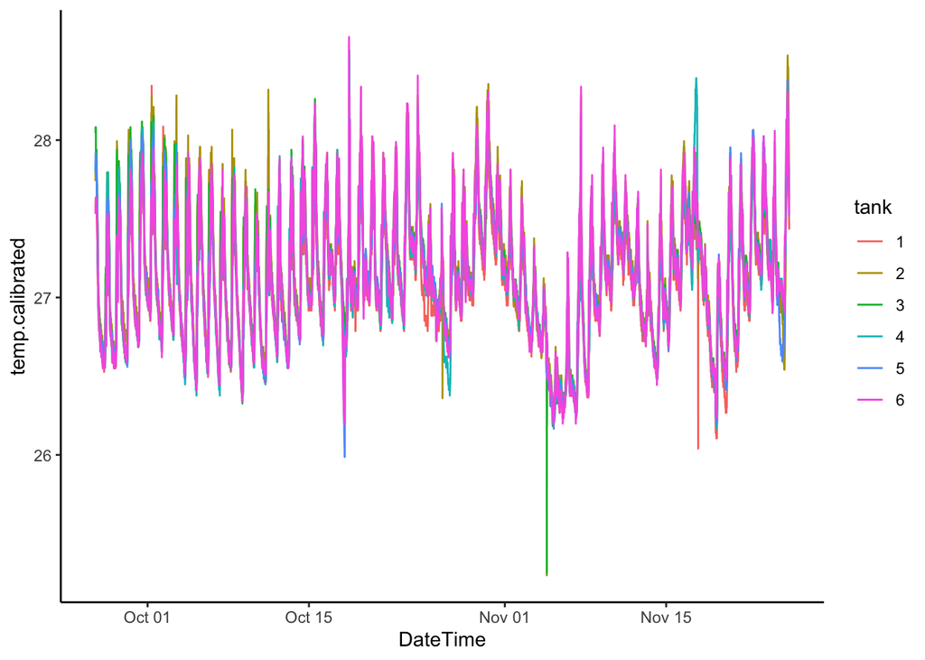

```r
temp_plot<-pendants%>%
  filter(DateTime > as.POSIXct('2022-09-26 11:20:00', tz="Pacific/Tahiti"))%>%

  ggplot(aes(x=DateTime, y=temp.calibrated, colour=tank))+
  geom_line()+
  theme_classic(); temp_plot
```

Temperature was even throughout tanks after this date.

Plot temperature time series by treatment.

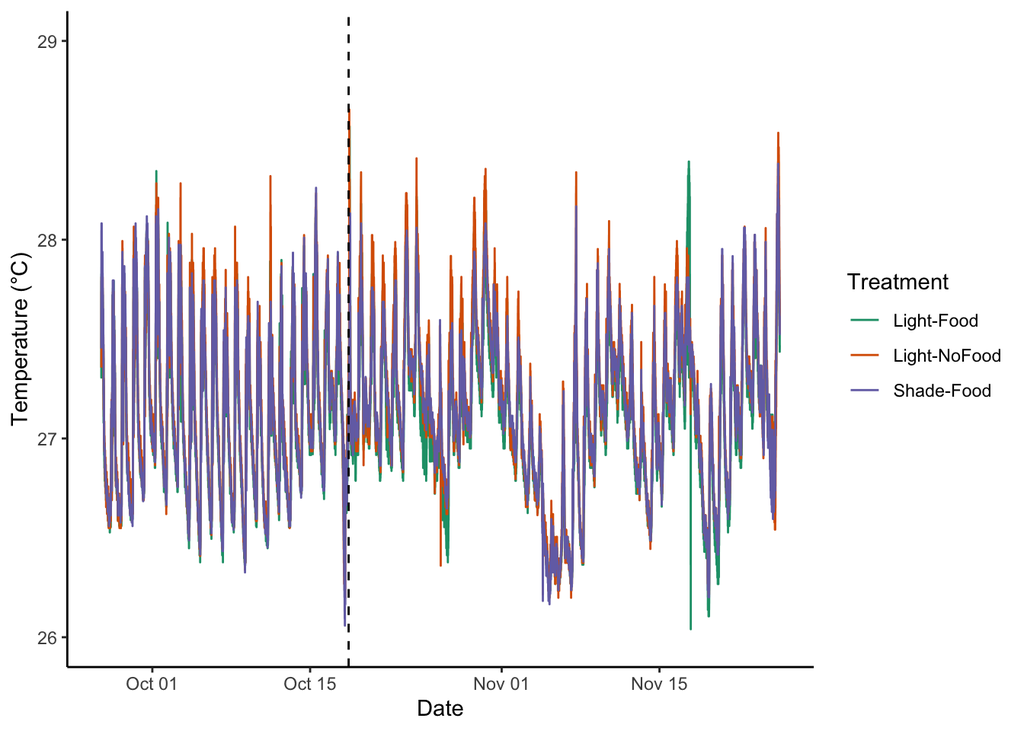

```r
temp_plot_treatment<-pendants%>%

  ggplot(aes(x=DateTime, y=temp.calibrated, colour=treatment))+
  geom_line()+
  ylim(26, 29)+
  scale_colour_brewer(palette = "Dark2", name="Treatment")+
  geom_vline(xintercept = as.POSIXct("2022-10-18 10:00:00", tz="Pacific/Tahiti"), linetype="dashed",
                color = "black", size=0.5)+
  ylab("Temperature (°C)")+
  xlab("Date")+
  theme_classic(); temp_plot_treatment
```

```r
ggsave("figures/environmental/timeseries_temp_treatment.png", temp_plot_treatment, width=8, height=6)
```

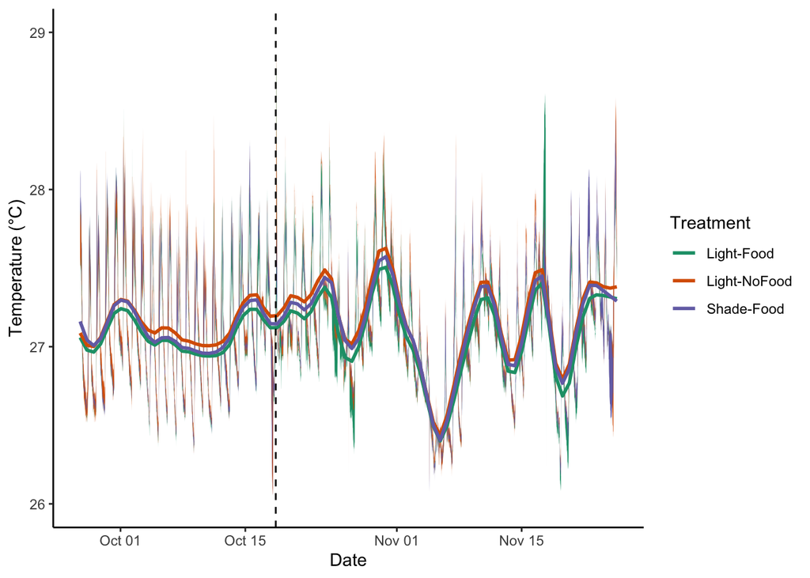

```r
temp_plot_treatment_smooth<-pendants%>%
  group_by(treatment, DateTime)%>%
  summarise(mean=mean(temp.calibrated, na.rm=TRUE), sd=sd(temp.calibrated, na.rm=TRUE), sem=sd/sqrt(6), upper=mean+sd, lower=mean-sd)%>%

  ggplot(aes(x=DateTime, y=mean, colour=treatment, fill=treatment))+
  #geom_line()+
  geom_ribbon(aes(ymin = lower, ymax = upper), alpha = 1, colour = NA, show.legend=FALSE) +
  geom_smooth(method="loess", span=0.1, se=FALSE, aes(fill=treatment), alpha=0.3) +
  ylim(26, 29)+
  ylab("Temperature (°C)")+
  xlab("Date")+
  scale_fill_brewer(palette = "Dark2", name="Treatment")+
  scale_colour_brewer(palette = "Dark2", name="Treatment")+
  geom_vline(xintercept = as.POSIXct("2022-10-18 10:00:00", tz="Pacific/Tahiti"), linetype="dashed",
                color = "black", size=0.5)+
  theme_classic(); temp_plot_treatment_smooth
```

```r
ggsave("figures/environmental/timeseries_temp_smooth.png", temp_plot_treatment_smooth, width=8, height=6)
```

## Plot light

Plot over time by tank in par units

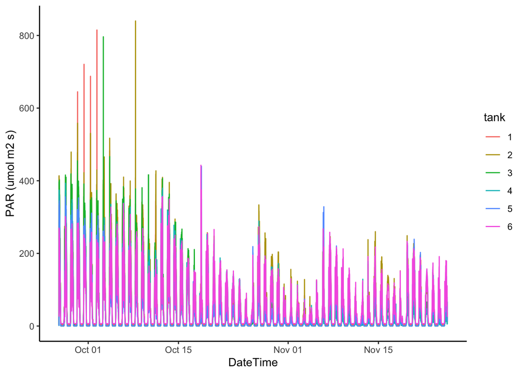

```r
light_plot<-pendants%>%
  ggplot(aes(x=DateTime, y=par, colour=tank))+
  ylab("PAR (umol m2 s)")+
  geom_line()+
  theme_classic(); light_plot
```

Plot by lux units

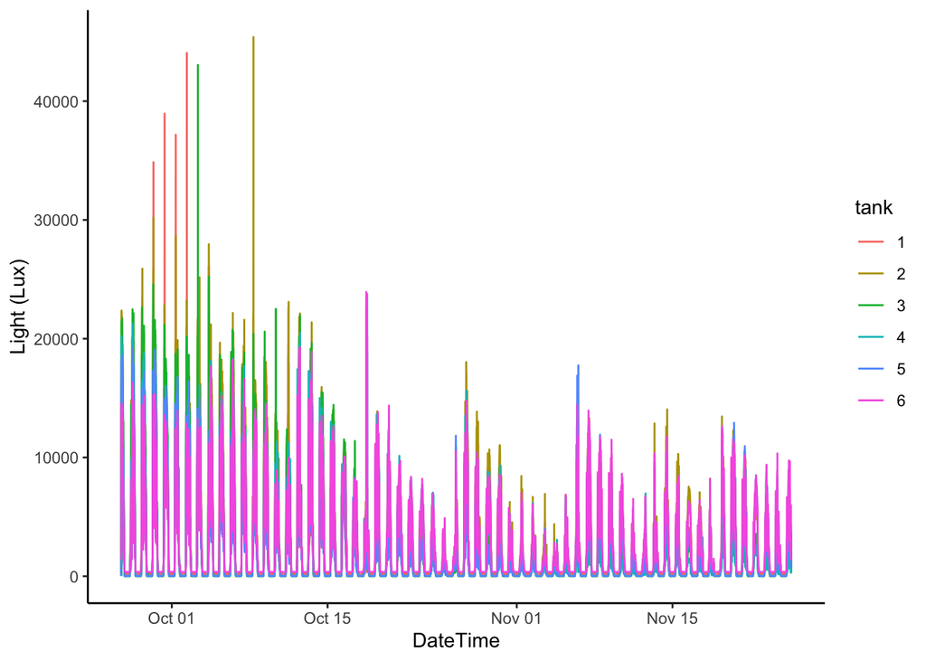

```r
lux_plot<-pendants%>%
  ggplot(aes(x=DateTime, y=lux.calibrated, colour=tank))+
  ylab("Light (Lux)")+
  geom_line()+
  theme_classic(); lux_plot
```

Plot light time series by treatment.

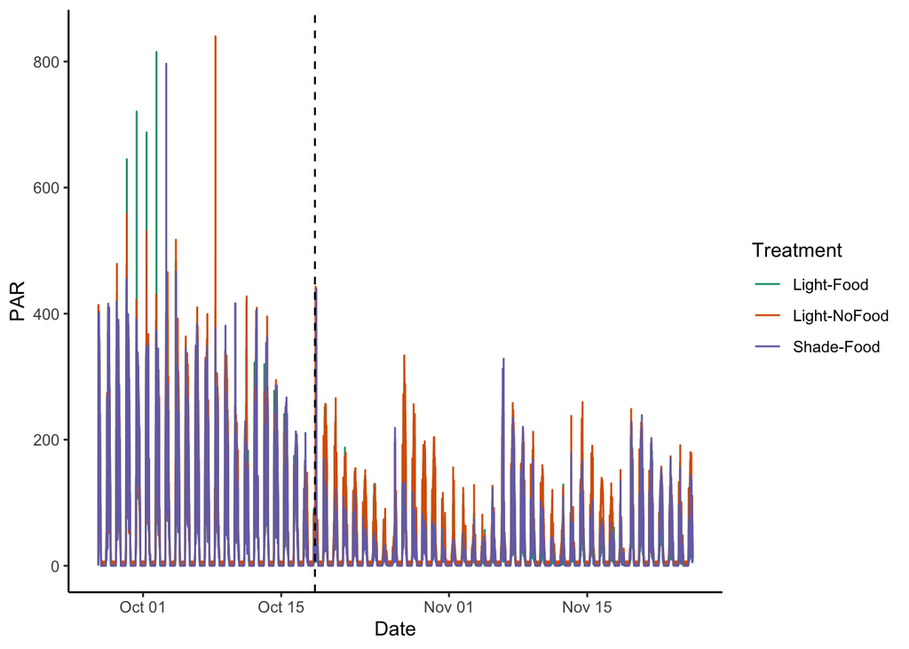

```r
light_plot_treatment<-pendants%>%

  ggplot(aes(x=DateTime, y=par, colour=treatment))+
  geom_line()+
  scale_colour_brewer(palette = "Dark2", name="Treatment")+
  geom_vline(xintercept = as.POSIXct("2022-10-18 10:00:00", tz="Pacific/Tahiti"), linetype="dashed",
                color = "black", size=0.5)+
  ylab("PAR")+
  xlab("Date")+
  theme_classic(); light_plot_treatment
```

```r
ggsave("figures/environmental/timeseries_light_treatment.png", light_plot_treatment, width=8, height=6)
```

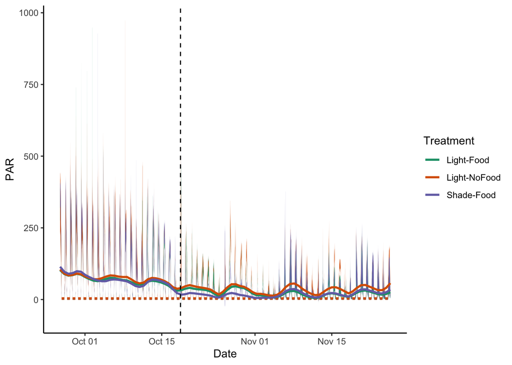

```r
light_plot_treatment_smooth<-pendants%>%
  group_by(treatment, DateTime)%>%
  summarise(mean=mean(par, na.rm=TRUE), sd=sd(par, na.rm=TRUE), sem=sd/sqrt(6), upper=mean+sd, lower=mean-sd)%>%

  ggplot(aes(x=DateTime, y=mean, colour=treatment, fill=treatment))+
  #geom_line()+
  geom_ribbon(aes(ymin = lower, ymax = upper), alpha = 1, colour = NA, show.legend=FALSE) +
  geom_smooth(method="loess", span=0.1, se=FALSE, aes(fill=treatment), alpha=0.3) +
  ylab("PAR")+
  xlab("Date")+
  scale_fill_brewer(palette = "Dark2", name="Treatment")+
  scale_colour_brewer(palette = "Dark2", name="Treatment")+
  geom_vline(xintercept = as.POSIXct("2022-10-18 10:00:00", tz="Pacific/Tahiti"), linetype="dashed",
                color = "black", size=0.5)+
  theme_classic(); light_plot_treatment_smooth
```

```r
ggsave("figures/environmental/timeseries_light_smooth.png", light_plot_treatment_smooth, width=8, height=6)
```

# Daily measurements

## Read in file

Read in daily measurements file.

```r
daily<-read_csv("data/environmental/daily_measurements/daily_measurements.csv")
daily$date<-as.Date(daily$date, format="%m/%d/%y")
daily$tank<-as.factor(daily$tank)
daily$tris.date<-as.character(daily$tris.date)
```

## Calculate pH

Calculate the calibration curve from the Tris calibration and calculate pH on the total scale from pH.mV.

```r
pHcalib<-read_csv("data/environmental/20220924_Tris_Calibration.csv")
pHcalib$tris.date<-as.character(pHcalib$tris.date)

pHSlope<-pHcalib %>%
  nest_by(tris.date)%>%
  mutate(fitpH = list(lm(mVTris~TTris, data = pHcalib))) %>% # linear regression of mV and temp of the tris
  summarise(broom::tidy(fitpH)) %>% # make the output tidy
  select(tris.date, term, estimate) %>%
  pivot_wider(names_from = term, values_from = estimate) %>%# put slope and intercept in their own column
  left_join(daily, ., by="tris.date") %>% # join with the pH sample data
  mutate(mVTris = temp.C*TTris + `(Intercept)`) %>%# calculate the mV of the tris at temperature in which the pH of the tanks were measured
  mutate(pH = pH(Ex=pH.mV,Etris=mVTris,S=sal.psu,T=temp.C)) # calculate pH of the tanks using the pH seacarb function
```

pH is now calculated as Total pH in the “pH” column. Now select the desired columns to analyze further.

```r
daily_calc<-pHSlope%>%
  select(date, time, tank, treatment, Period, temp.C, pH, sal.psu, flow.mL.5s.initial, par.center)
```

## Calculate flow

```r
daily_calc<-daily_calc%>%
  mutate(flow.L.min=(flow.mL.5s.initial*12)/1000)%>%
  select(!flow.mL.5s.initial)
```

## Calculate mean light value

Calculate the mean light value (PAR) as an average of all light measurements in the 5 positions in each tank at each measurement.

```r
# daily_calc<-daily_calc%>%
#   mutate(mean.par=rowMeans(across(starts_with("par")), na.rm=TRUE)) %>%
#   select(date, time, tank, temp.C, pH, sal.psu, flow.L.min, par.center, mean.par)

daily_calc$par.center <- as.numeric(as.character(daily_calc$par.center))
```

## Correct salinity values

The salinity probe was calibrated on 20221026 by HP to 1000 uS/cm standard. The measurements before this date need to be corrected by applying a conversion factor to all measurements before 20221026.

```r
#calculate the average salinity values before and after the calibration
before<-daily_calc%>%
  filter(date<"2022-10-26")%>%
  summarise(correction=mean(sal.psu)); before
```

```
## # A tibble: 1 × 1
##   correction
##        <dbl>
## 1       38.1
```

```r
#before = 38.1

after<-daily_calc%>%
  filter(date>"2022-10-25")%>%
  summarise(correction=mean(sal.psu)); after
```

```
## # A tibble: 1 × 1
##   correction
##        <dbl>
## 1       35.1
```

```r
#after=35.1

correction<-before-after; correction
```

```
##   correction
## 1   3.029809
```

```r
#correction of 3.03 psu
```

Apply the correction by subtracting the value from all measurements before 2022-10-26.

```r
daily_calc<-daily_calc%>%
  mutate(sal.psu.cor=ifelse(date<="2022-10-26", sal.psu-correction$correction, sal.psu))
```

This conversion value is the same calculated for larval tanks in AH scripts.

We will now use sal.psu.cor for future analyses.

## Change data format to long format

```r
daily_calc.long <-daily_calc %>%
  select(!sal.psu)%>%
  pivot_longer(cols=temp.C:sal.psu.cor,
  names_to = "metric",
  values_to = "value")
```

## Plot metrics of interest

Plot by tank.

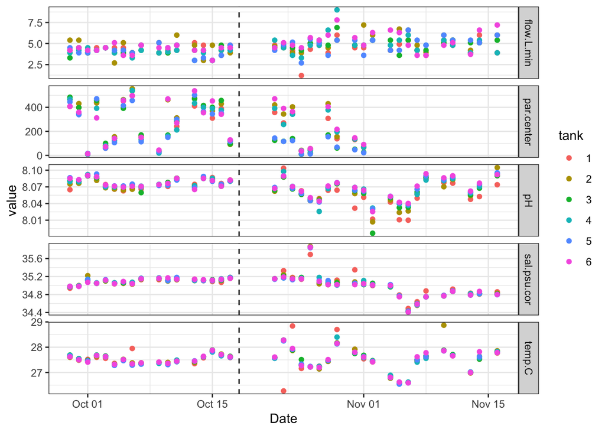

```r
daily_tanks<-daily_calc.long %>%
  ggplot(aes(x=date, y=value, colour=tank))+
  geom_point()+
  geom_vline(xintercept = as.numeric(ymd("2022-10-18")), linetype="dashed",
                color = "black", size=0.5)+
  xlab("Date")+
  facet_grid(metric ~ ., scales = "free")+
  scale_fill_brewer(palette = "Dark2")+
  theme_bw(); daily_tanks
```

```r
ggsave(filename="figures/environmental/tank_daily_measurements.png", plot=daily_tanks, dpi=300, width=8, height=10, units="in")
```

Plot by treatment

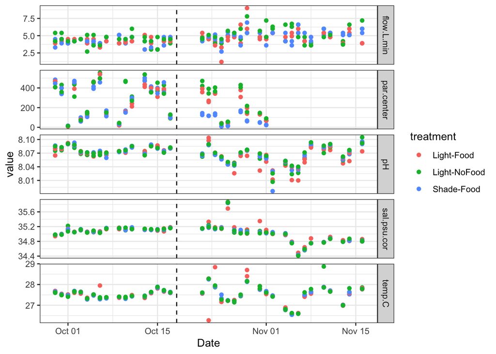

```r
daily_plots<-daily_calc.long %>%
  ggplot(aes(x=date, y=value, colour=treatment))+
  geom_point()+
  geom_vline(xintercept = as.numeric(ymd("2022-10-18")), linetype="dashed",
                color = "black", size=0.5)+
  xlab("Date")+
  facet_grid(metric ~ ., scales = "free")+
  scale_fill_brewer(palette = "Dark2")+
  theme_bw(); daily_plots
```

```r
ggsave(filename="figures/environmental/daily_measurements.png", plot=daily_plots, dpi=300, width=8, height=10, units="in")
```

Separate into Acclimation period and Exposure Period

```r
exposure.data <- daily_calc.long %>%
  filter(Period=="Exposure")
```

Plot by treatment

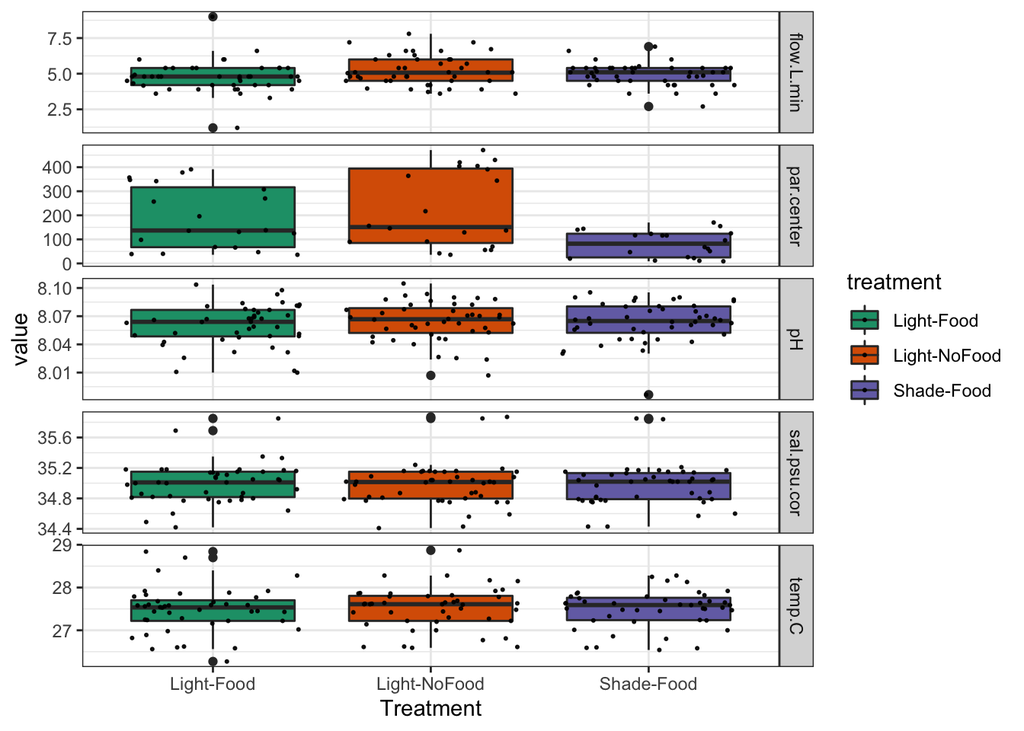

```r
daily_plots<-exposure.data %>%
  ggplot(aes(x=treatment, y=value, fill=treatment))+
  geom_boxplot() +
  geom_jitter(color="black", size=0.4, alpha=0.9) +
  geom_vline(xintercept = as.numeric(ymd("2022-10-18")), linetype="dashed",
                color = "black", size=0.5)+
  xlab("Treatment")+
  facet_grid(metric ~ ., scales = "free")+
  scale_fill_brewer(palette = "Dark2")+
  theme_bw(); daily_plots
```

```r
ggsave(filename="figures/environmental/treatment_daily_measurements.png", plot=daily_plots, dpi=300, width=8, height=10, units="in")
```

## Test for differences between tanks

```r
daily_calc_exposure <- daily_calc%>%
  filter(Period=="Exposure")

#Temp
summary(aov(temp.C~tank, data=daily_calc_exposure))
```

```
##              Df Sum Sq Mean Sq F value Pr(>F)
## tank          5  0.098  0.0195   0.079  0.995
## Residuals   126 30.981  0.2459
```

```r
#pH
summary(aov(pH~tank, data=daily_calc_exposure))
```

```
##              Df  Sum Sq   Mean Sq F value Pr(>F)
## tank          5 0.00195 0.0003899   0.851  0.516
## Residuals   126 0.05773 0.0004582
```

```r
#Salinity
summary(aov(sal.psu~tank, data=daily_calc_exposure))
```

```
##              Df Sum Sq Mean Sq F value Pr(>F)
## tank          5   0.02  0.0043   0.002      1
## Residuals   126 313.93  2.4915
```

```r
#Flow
summary(aov(flow.L.min~tank, data=daily_calc_exposure))
```

```
##              Df Sum Sq Mean Sq F value Pr(>F)
## tank          5   7.84  1.5680   1.594  0.167
## Residuals   126 123.97  0.9839
```

```r
#Light
summary(aov(par.center~tank, data=daily_calc_exposure))
```

```
##             Df Sum Sq Mean Sq F value Pr(>F)
## tank         5 220038   44008    2.79 0.0259 *
## Residuals   54 851711   15772
## ---
## Signif. codes:  0 '***' 0.001 '**' 0.01 '*' 0.05 '.' 0.1 ' ' 1
## 72 observations deleted due to missingness
```

## Test for differences between Treatments

```r
daily_calc_exposure <- daily_calc%>%
  filter(Period=="Exposure")

#Temp
summary(aov(temp.C~treatment, data=daily_calc_exposure))
```

```
##              Df Sum Sq Mean Sq F value Pr(>F)
## treatment     2  0.062 0.03096   0.129  0.879
## Residuals   129 31.016 0.24044
```

```r
#pH
summary(aov(pH~treatment, data=daily_calc_exposure))
```

```
##              Df  Sum Sq   Mean Sq F value Pr(>F)
## treatment     2 0.00045 0.0002236   0.487  0.616
## Residuals   129 0.05923 0.0004592
```

```r
#Salinity
summary(aov(sal.psu~treatment, data=daily_calc_exposure))
```

```
##              Df Sum Sq Mean Sq F value Pr(>F)
## treatment     2   0.01  0.0062   0.003  0.997
## Residuals   129 313.93  2.4336
```

```r
#Flow
summary(aov(flow.L.min~treatment, data=daily_calc_exposure))
```

```
##              Df Sum Sq Mean Sq F value Pr(>F)
## treatment     2   4.68  2.3375   2.372 0.0974 .
## Residuals   129 127.13  0.9855
## ---
## Signif. codes:  0 '***' 0.001 '**' 0.01 '*' 0.05 '.' 0.1 ' ' 1
```

```r
#Light
summary(aov(par.center~treatment, data=daily_calc_exposure))
```

```
##             Df Sum Sq Mean Sq F value  Pr(>F)
## treatment    2 217323  108662   7.249 0.00157 **
## Residuals   57 854426   14990
## ---
## Signif. codes:  0 '***' 0.001 '**' 0.01 '*' 0.05 '.' 0.1 ' ' 1
## 72 observations deleted due to missingness
```